# TD - Introduction à Linux et à l’Environnement Conda

Ghislain Bidaut, Plateforme Cibi, CRCM Aix-Marseille Université

16/09/2021

# 1 TD Partie 1: Familiarisation avec l’environnement Linux

## 1.2 Manipulation d’un fichier à plusieurs colonnes

- Télécharger le fichier d’annotations de la levure à l’adresse ftp://ftp.ensemblgenomes.org/pub/release-37/fungi/gtf/saccharomyces_cerevisiae/Saccharomyces_cerevisiae.R64-1-1.37.gtf.gz
- Décompresser ce fichier
- Afficher les 5 premières lignes
- Afficher les 4 premières colonnes
- Créer une liste triée unique des gènes présents dans ce fichier et la stocker dans un fichier texte. Il faut que les guillemets (") soient supprimés.

## 1.3 Création d’un script bash

- Ouvrir l’éditeur de fichiers `gedit` ( ou votre éditeur préféré).
- Ecrire un script `bash` appelé `creation_arborescence.sh` qui recrée l’arborescence suivante de manière automatisée.
- Commenter ce script en détaillant les opérations.

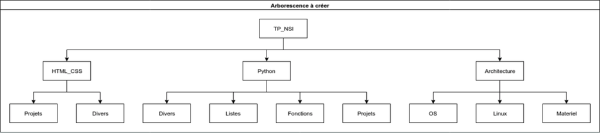

# 2 TD Partie 2 : Installation complète d’un environnement de travail RNA-Seq

## 2.1 Installation de l’environnement Conda

- Connectez vous au cluster de l’IFB (IFB-Core).

- Installer **miniconda** dans votre environnement.
- Créer un environnement `rnaseq`.
- Activer cet environnement.
- Installation des outils suivants: `fastqc`, `multiqc`, `bwa`.
- Tester ces outils et regarder leurs options de ligne de commande. En particulier, comment spécifie t-on les entrées-sorties ?
- Enregistrer la configuration de cet environnement dans un fichier `RNAseq_env.yml`.
- Désactiver l’environnement `rnaseq`.
- Effacer l’environnement `rnaseq`.
- Le recréer sous le nom `ngs` à partir du fichier `RNAseq_env.yml`.

Cette œuvre est mise à disposition selon les termes de la [Licence Creative Commons:](http://creativecommons.org/licenses/by-nc-nd/4.0/)  
Attribution - Pas d’Utilisation Commerciale - Pas de Modification 4.0 International (CC BY-NC-ND 4.0).